# Google Data Analytics Capstone Project 1

Stanley Cheng

2021/9/23

### Share and Visualization

In this part, I will share those insight found from the data analysis.

- Overall analysis

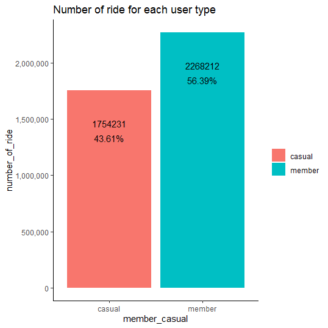

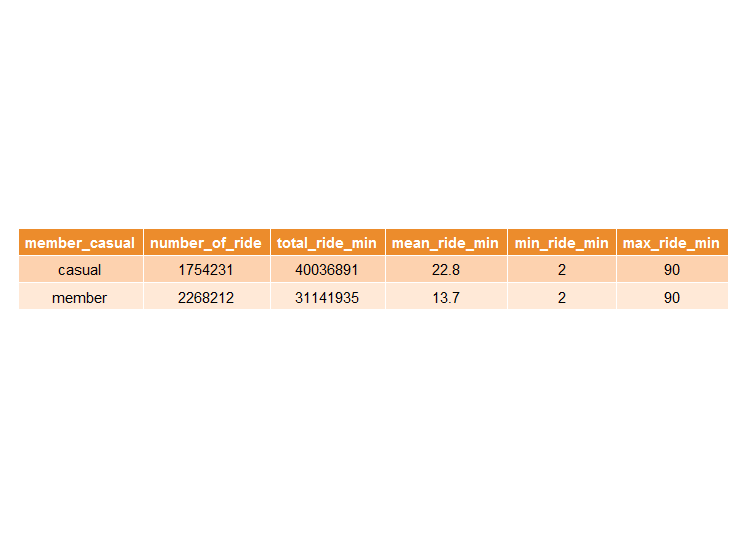

- Analysis by Month

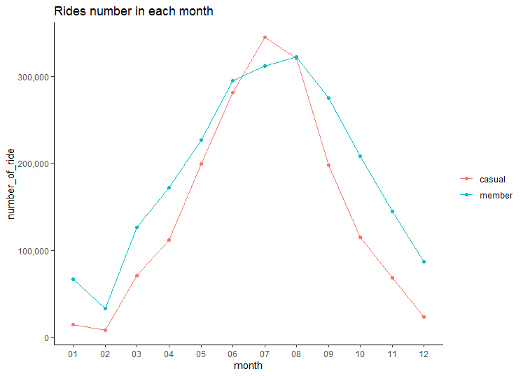

Insight and Interpretation:  
A seasonal cyclic pattern of rides number is observed in both members and casuals. The rides number increase significantly from February and reaches the peak at July and August. Then the numbers drastically drop at the end of year. After checking the average monthly temperature, a similar seasonal pattern is also observed. Therefore a possible explanation is: During the spring and summer time (Feb to Sep), the weather is warmer and suitable to ride. And during the winter time (Oct-Feb) time, it is too cold to ride outside and people tends to stop riding bike under such weather condition.

- Analysis by Hour:

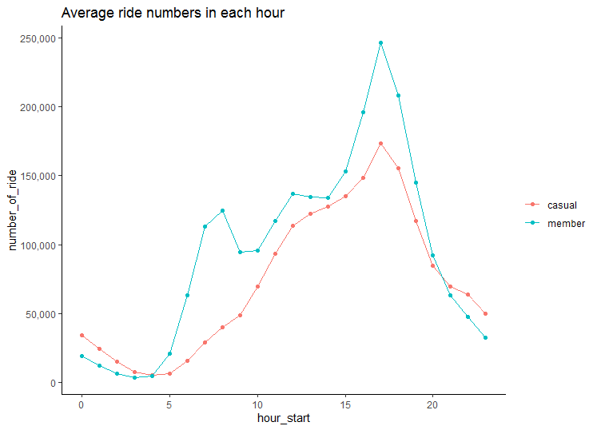

Insight and Interpretation:

For the ride number, a daily cycle of rides number are observed in both members and casuals. Both ride numbers are significantly bigger during daytime and they reach the peaks at afternoon time. The numbers are then drastically drop when getting into evening and night time. A possible explanation is: During the day time people are more likely to make a ride. They may use the bike to go to shops, schools or work. And during evening and night time, people are less likely to bike as they go to rest and sleep.

- Analysis by Weekday

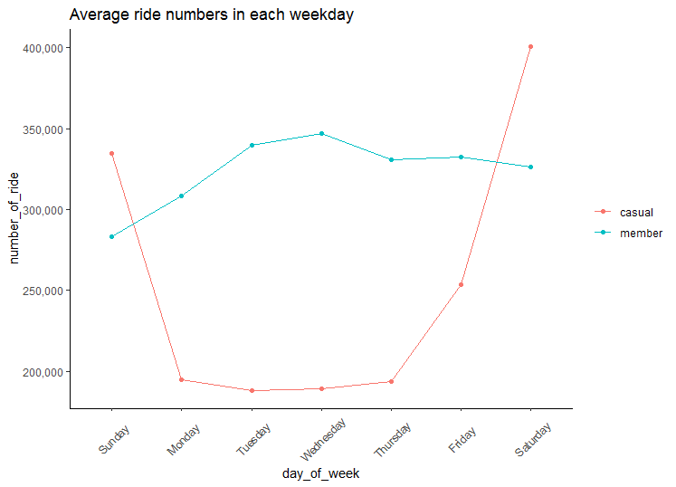

Insight and Interpretation:

Members and casuals demonstrate a different pattern of ride number across a week. Members tends to have a steady and even distribution across a week. Casuals have a significant low rides on weekdays (Monday to Friday), but a shape increase of ride number during Saturday and Sunday. A possible explanation is: Members usually have a regular biking practice and they have incorporated biking in their daily live. They may biking for work, school or regular exercise etc. On the other hand, casuals have no such habit and they only take rides when they are in holiday. (Saturday and Sunday)

- Analysis by starting location

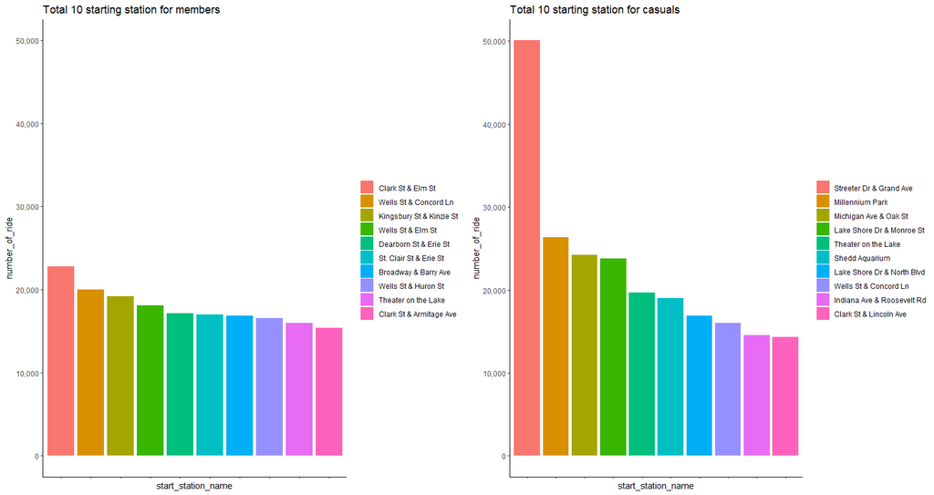

Insight and Interpretation:

For members, their top 10 start locations are quite similar in ride numbers (around 20000 rides each). For casuals, “Streeter Dr & Grand Ave” are their top leading start location and it has a significant large number of biking compared to other locations.

- Analysis by Route

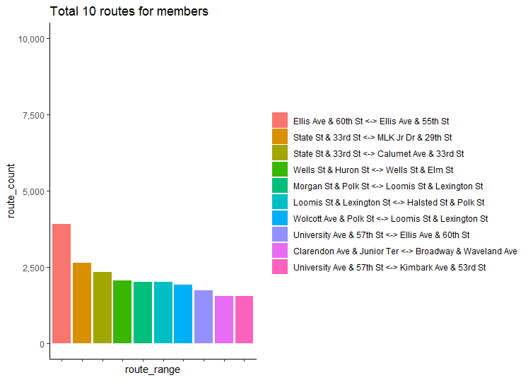

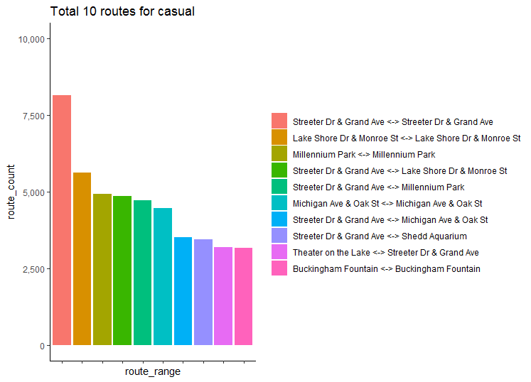

Insight and Interpretation:

These are the top 10 routes for members and casual. They represent different bike travel pattern or location segment between members and casuals.  
For members, locations like “Ellis Ave & 60 St”, “Ellis Ave & 60 St”, “State St & 33 St”, “Loomis St & Lexington St” etc. are appeared in the lists for more than one time. For casuals, locations like “Streeter Dr & Grand Ave”, “Lake Shore Dr & Monroe St”, “Michigan Ave & Oak St” and “Millennium Park” are appeared in the lists for more than one time. Beside, most of the location are the travel hotspot or landmarks of the city. And the top 3 casual routes have the same starting and ending location. One of the possible interpretation is that casuals may just take a sightseeing or in these area during their tours.

### Possible further follow-ups:

1. Revised pricing or segment strategy, there may be ways to add new segment to improve revenue.
2. Data checking or verification, find out the reason of missing or error data in record field.
3. Detailed analysis in multi-variable factors.

This is the end my data analysis for Cyclistic company. Thanks for reading till the end and Feel free to comment.